# stock market forecasting

```python
!pip install pmdarima
```

```
     ━━━━━━━━━━━━━━━━━━━━━━━━━━━━━━━━━━━━━━━━ 1.8/1.8 MB 59.0 MB/s eta 0:00:00
```

```python
import os
import warnings
warnings.filterwarnings('ignore')
import numpy as np
import pandas as pd
import matplotlib.pyplot as plt
plt.style.use('seaborn-white')
from pylab import rcParams
rcParams['figure.figsize'] = 10, 6
from statsmodels.tsa.stattools import adfuller
from statsmodels.tsa.seasonal import seasonal_decompose

from pmdarima.arima import auto_arima
from statsmodels.tsa.arima.model import ARIMA

from statsmodels.graphics.tsaplots import plot_acf,plot_pacf

from sklearn.metrics import mean_squared_error, mean_absolute_error
import math
```

```python
dateparse = lambda dates: pd.datetime.strptime(dates, '%Y-%m-%d')
stock_data=pd.read_table('/content/sample_data/acgl.us.txt',sep=',',index_col='Date',parse_dates=['Date'],date_parser=dateparse)
```

```python
stock_data.head()
```

| Date | Open | High | Low | Close | Volume | OpenInt |
| --- | --- | --- | --- | --- | --- | --- |
| 2005-02-25 | 13.583 | 13.693 | 13.430 | 13.693 | 156240 | 0 |
| 2005-02-28 | 13.697 | 13.827 | 13.540 | 13.827 | 370509 | 0 |
| 2005-03-01 | 13.780 | 13.913 | 13.720 | 13.760 | 224484 | 0 |
| 2005-03-02 | 13.717 | 13.823 | 13.667 | 13.810 | 286431 | 0 |
| 2005-03-03 | 13.783 | 13.783 | 13.587 | 13.630 | 193824 | 0 |

```python
stock_data.describe()
```

|  | Open | High | Low | Close | Volume | OpenInt |
| --- | --- | --- | --- | --- | --- | --- |
| count | 3201.000000 | 3201.000000 | 3201.000000 | 3201.000000 | 3.201000e+03 | 3201.0 |
| mean | 41.800246 | 42.127681 | 41.465992 | 41.826403 | 7.830475e+05 | 0.0 |
| std | 23.728163 | 23.847994 | 23.593876 | 23.730770 | 6.482674e+05 | 0.0 |
| min | 13.170000 | 13.270000 | 11.010000 | 13.180000 | 5.236800e+04 | 0.0 |
| 25% | 22.653000 | 22.907000 | 22.370000 | 22.643000 | 3.591570e+05 | 0.0 |
| 50% | 33.100000 | 33.430000 | 32.800000 | 33.150000 | 5.823510e+05 | 0.0 |
| 75% | 57.550000 | 57.890000 | 57.240000 | 57.550000 | 1.033461e+06 | 0.0 |
| max | 102.450000 | 102.600000 | 101.840000 | 102.380000 | 1.388090e+07 | 0.0 |

```python
stock_data.info()
```

```
<class 'pandas.core.frame.DataFrame'>
DatetimeIndex: 3201 entries, 2005-02-25 to 2017-11-10
Data columns (total 6 columns):
 #   Column   Non-Null Count  Dtype
---  ------   --------------  -----
 0   Open     3201 non-null   float64
 1   High     3201 non-null   float64
 2   Low      3201 non-null   float64
 3   Close    3201 non-null   float64
 4   Volume   3201 non-null   int64
 5   OpenInt  3201 non-null   int64
dtypes: float64(4), int64(2)
memory usage: 175.1 KB
```

```python
stock_data.isna().sum()
```

```
Open       0
High       0
Low        0
Close      0
Volume     0
OpenInt    0
dtype: int64
```

```python
df_close=stock_data['Close']
```

```python
df_close=pd.DataFrame(df_close)
```

```python
df_close.head()
```

| Date | Close |
| --- | --- |
| 2005-02-25 | 13.693 |
| 2005-02-28 | 13.827 |
| 2005-03-01 | 13.760 |
| 2005-03-02 | 13.810 |
| 2005-03-03 | 13.630 |

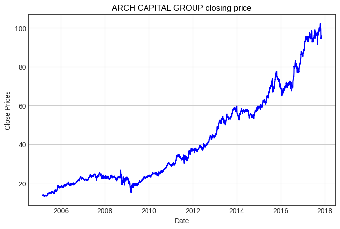

```python
#Visualize the per day closing price of the stock.

#plot close price
plt.figure(figsize=(8,5))
plt.grid(True)
plt.xlabel('Date')
plt.ylabel('Close Prices')
plt.plot(df_close,c='b')
plt.title('ARCH CAPITAL GROUP closing price',c='k')
plt.show()
```

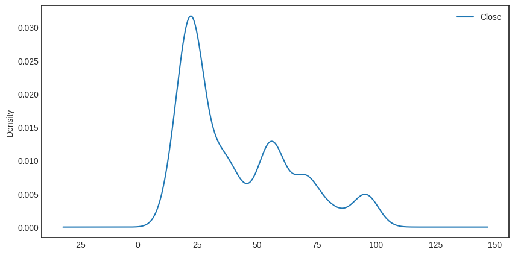

```python
#We can also visualize the data in our series through a probability distribution too.
#Distribution of the dataset
df_close.plot(kind='kde')
plt.show()
```

Also, a given time series is thought to consist of three systematic components including level, trend, seasonality, and one non-systematic component called noise.

These components are defined as follows:

Level: The average value in the series.

Trend: The increasing or decreasing value in the series.

Seasonality: The repeating short-term cycle in the series.

Noise: The random variation in the series.

First, we need to check if a series is stationary or not because time series analysis only works with stationary data.

ADF (Augmented Dickey-Fuller) Test

The Dickey-Fuller test is one of the most popular statistical tests. It can be used to determine the presence of unit root in the series, and hence help us understand if the series is stationary or not. The null and alternate hypothesis of this test is:

Null Hypothesis: The series has a unit root (value of a =1)

Alternate Hypothesis: The series has no unit root.

If we fail to reject the null hypothesis, we can say that the series is non-stationary. This means that the series can be linear or difference stationary.

If both mean and standard deviation are flat lines(constant mean and constant variance), the series becomes stationary.

**So let's check for stationarity:

```python
#Test for staionarity
def test_stationarity(timeseries):
    #Determing rolling statistics
    rolmean = timeseries.rolling(12).mean()
    rolstd = timeseries.rolling(12).std()
    #Plot rolling statistics:
    plt.plot(timeseries, color='blue',label='Original')
    plt.plot(rolmean, color='red', label='Rolling Mean')
    plt.plot(rolstd, color='black', label = 'Rolling Std')
    plt.legend(loc='best')
    plt.title('Rolling Mean and Standard Deviation')
    plt.show(block=False)
    print("Results of dickey fuller test")
    adft = adfuller(timeseries,autolag='AIC')
    # output for dft will give us without defining what the values are.
    #hence we manually write what values does it explains using a for loop
    output = pd.Series(adft[0:4],index=['Test Statistics','p-value','No. of lags used','Number of observations used'])
    for key,values in adft[4].items():
        output['critical value (%s)'%key] =  values
    print(output)
```

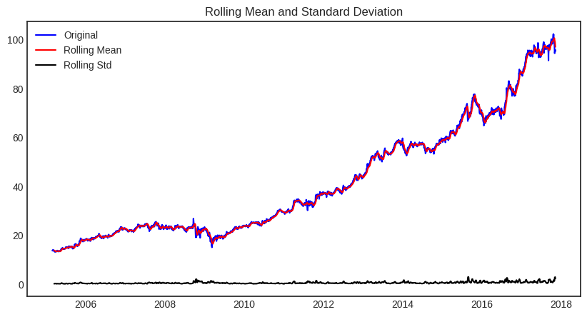

```
Results of dickey fuller test
Test Statistics                   1.374899
p-value                           0.996997
No. of lags used                  5.000000
Number of observations used    3195.000000
critical value (1%)              -3.432398
critical value (5%)              -2.862445
critical value (10%)             -2.567252
dtype: float64
```

```python
test_stationarity(df_close)
#Results of dickey fuller test
```

We see that the p-value is greater than 0.05 so we cannot reject the Null hypothesis. Also, the test statistics is greater than the critical values. so the data is non-stationary.

In order to perform a time series analysis, we may need to separate seasonality and trend from our series. The resultant series will become stationary through this process.

So let us separate Trend and Seasonality from the time series.

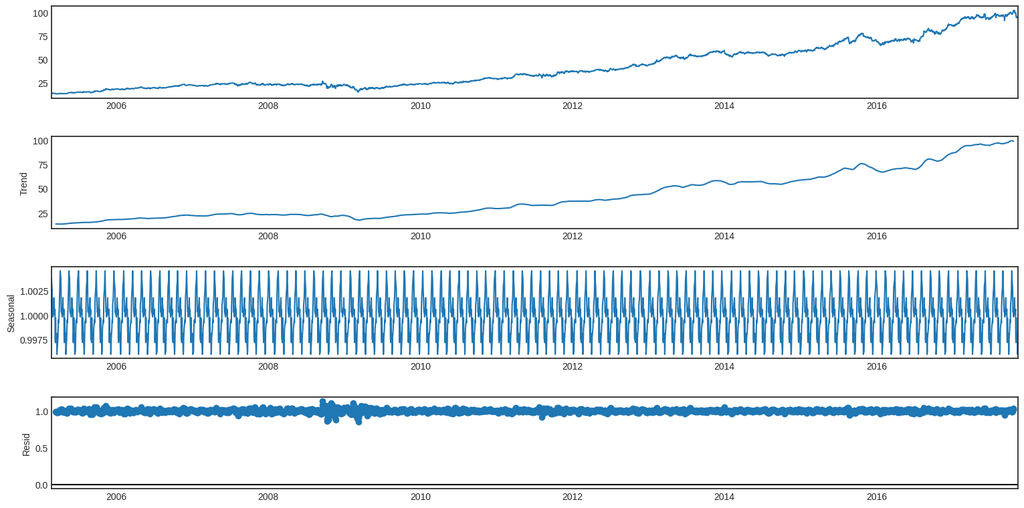

```python
#To separate the trend and the seasonality from a time series,
# we can decompose the series using the following code.
result = seasonal_decompose(df_close, model='multiplicative',period=30)
fig = plt.figure()
fig = result.plot()
fig.set_size_inches(16, 8)
plt.show()
```

[output not shown]

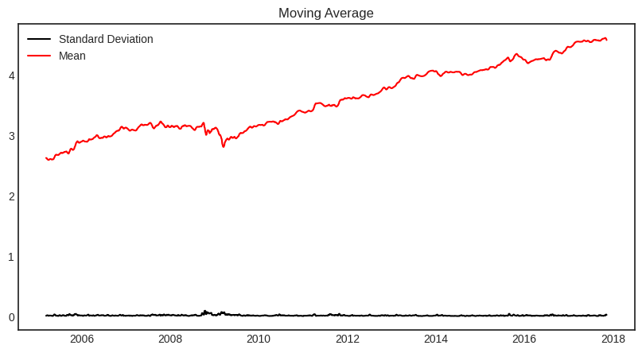

```python
#if not stationary then eliminate trend
#Eliminate trend
from pylab import rcParams
rcParams['figure.figsize'] = 10, 5
df_log = np.log(df_close)
moving_avg = df_log.rolling(12).mean()
std_dev = df_log.rolling(12).std()
plt.legend(loc='best')
plt.title('Moving Average')
plt.plot(std_dev, color ="black", label = "Standard Deviation")
plt.plot(moving_avg, color="red", label = "Mean")
plt.legend()
plt.show()
```

Now we are going to create an ARIMA model and will train it with the closing price of the stock on the train data. So let us split the data into training and test set and visualize it.

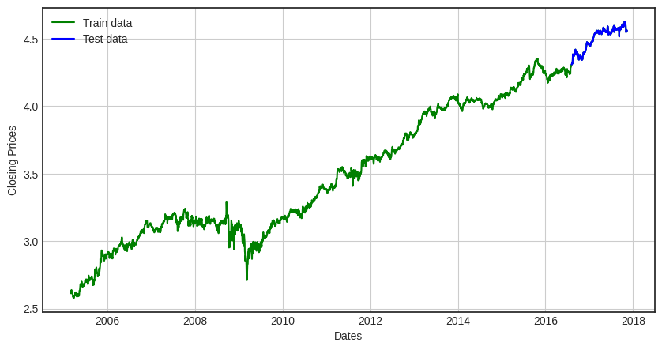

```python
#split data into train and training set
train_data, test_data = df_log[3:int(len(df_log)*0.9)], df_log[int(len(df_log)*0.9):]
plt.figure(figsize=(10,5))
plt.grid(True)
plt.xlabel('Dates')
plt.ylabel('Closing Prices')
plt.plot(df_log, 'green', label='Train data')
plt.plot(test_data, 'blue', label='Test data')
plt.legend()
```

Its time to choose parameters p,q,d for ARIMA model. Last time we chose the value of p,d, and q by observing the plots of ACF and PACF but now we are going to use Auto ARIMA to get the best parameters without even plotting ACF and PACF graphs.

Auto ARIMA: Automatically discover the optimal order for an ARIMA model. The auto_arima function seeks to identify the most optimal parameters for an ARIMA model, and returns a fitted ARIMA model. This function is based on the commonly-used R function, forecast::auto.arima.

The auro_arima function works by conducting differencing tests (i.e., Kwiatkowski–Phillips–Schmidt–Shin, Augmented Dickey-Fuller or Phillips–Perron) to determine the order of differencing, d, and then fitting models within ranges of defined start_p, max_p, start_q, max_q ranges. If the seasonal optional is enabled, auto_arima also seeks to identify the optimal P and Q hyper- parameters after conducting the Canova-Hansen to determine the optimal order of seasonal differencing, D.

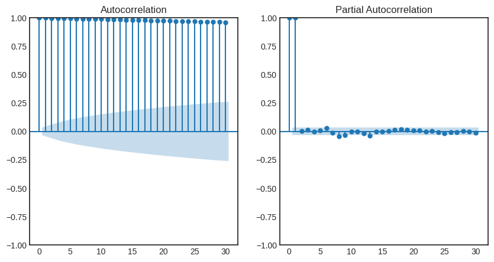

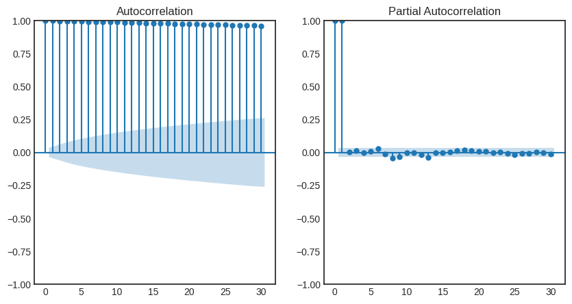

```python
fig, ax = plt.subplots(1, 2, figsize=(10, 5))
plot_acf(df_close,lags=30,ax=ax[0])
plot_pacf(df_close,lags=30,ax=ax[1])
```

```
Performing stepwise search to minimize aic
 ARIMA(0,1,0)(0,0,0)[0] intercept   : AIC=-16491.508, Time=0.40 sec
 ARIMA(1,1,0)(0,0,0)[0] intercept   : AIC=-16525.992, Time=0.21 sec
 ARIMA(0,1,1)(0,0,0)[0] intercept   : AIC=-16527.964, Time=1.99 sec
 ARIMA(0,1,0)(0,0,0)[0]             : AIC=-16488.323, Time=0.28 sec
 ARIMA(1,1,1)(0,0,0)[0] intercept   : AIC=-16527.157, Time=4.19 sec
 ARIMA(0,1,2)(0,0,0)[0] intercept   : AIC=-16527.120, Time=1.35 sec
 ARIMA(1,1,2)(0,0,0)[0] intercept   : AIC=-16528.810, Time=1.90 sec
 ARIMA(2,1,2)(0,0,0)[0] intercept   : AIC=inf, Time=3.97 sec
 ARIMA(1,1,3)(0,0,0)[0] intercept   : AIC=-16526.020, Time=3.67 sec
 ARIMA(0,1,3)(0,0,0)[0] intercept   : AIC=-16524.974, Time=5.98 sec
 ARIMA(2,1,1)(0,0,0)[0] intercept   : AIC=-16525.435, Time=1.33 sec
 ARIMA(2,1,3)(0,0,0)[0] intercept   : AIC=-16516.417, Time=0.93 sec
 ARIMA(1,1,2)(0,0,0)[0]             : AIC=-16527.597, Time=0.87 sec

Best model:  ARIMA(1,1,2)(0,0,0)[0] intercept
Total fit time: 27.131 seconds
                               SARIMAX Results
==============================================================================
Dep. Variable:                      y   No. Observations:                 2877
Model:               SARIMAX(1, 1, 2)   Log Likelihood                8269.405
Date:                Mon, 01 May 2023   AIC                         -16528.810
Time:                        12:25:59   BIC                         -16498.989
Sample:                             0   HQIC                        -16518.061
                               - 2877
Covariance Type:                  opg
==============================================================================
                 coef    std err          z      P>|z|      [0.025      0.975]
------------------------------------------------------------------------------
intercept   2.467e-05   7.12e-06      3.464      0.001    1.07e-05    3.86e-05
ar.L1          0.9538      0.009    104.140      0.000       0.936       0.972
ma.L1         -1.0708      0.015    -73.566      0.000      -1.099      -1.042
ma.L2          0.0877      0.012      7.504      0.000       0.065       0.111
sigma2         0.0002   2.32e-06     80.805      0.000       0.000       0.000
===================================================================================
Ljung-Box (L1) (Q):                   0.00   Jarque-Bera (JB):              7207.33
Prob(Q):                              0.97   Prob(JB):                         0.00
Heteroskedasticity (H):               0.30   Skew:                            -0.39
Prob(H) (two-sided):                  0.00   Kurtosis:                        10.72
===================================================================================

Warnings:
[1] Covariance matrix calculated using the outer product of gradients (complex-step).
```

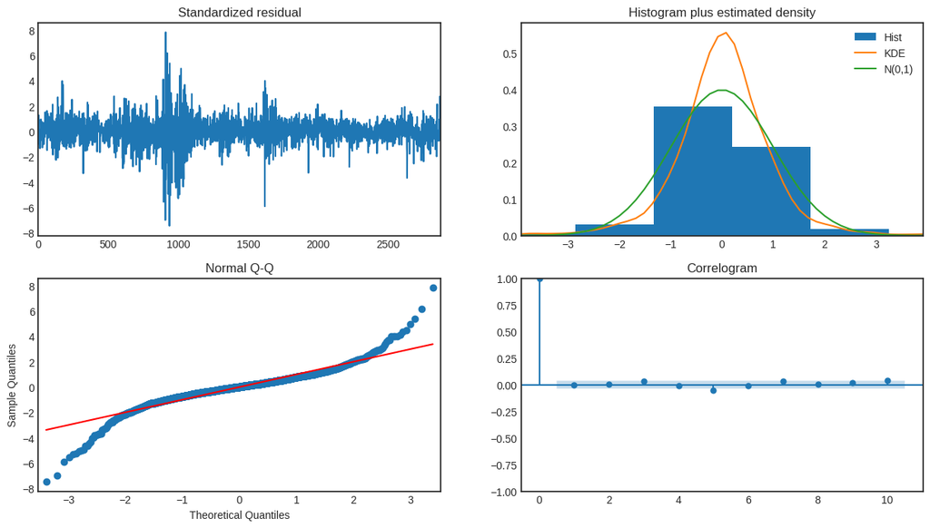

```python
model_autoARIMA = auto_arima(train_data, start_p=0, start_q=0,
                      test='adf',       # use adftest to find optimal 'd'
                      max_p=3, max_q=3, # maximum p and q
                      m=1,              # frequency of series
                      d=None,           # let model determine 'd'
                      seasonal=False,   # No Seasonality
                      start_P=0,
                      D=0,
                      trace=True,
                      error_action='ignore',
                      suppress_warnings=True,
                      stepwise=True)
print(model_autoARIMA.summary())
model_autoARIMA.plot_diagnostics(figsize=(15,8))
plt.show()
```

So how to interpret the plot diagnostics?

Bottom left: All the dots should fall perfectly in line with the red line. Any significant deviations would imply the distribution is skewed.

Bottom Right: The Correlogram, aka, ACF plot shows the residual errors are not autocorrelated. Any autocorrelation would imply that there is some pattern in the residual errors which are not explained in the model. So you will need to look for more X’s (predictors) to the model.

Next, create an ARIMA model with provided optimal parameters p, d and q.

### So the Auto ARIMA model provided the value of p,d, and q as 1, 1 and 2 respectively.

```python
#Modeling
# Build Model
model = ARIMA(train_data, order=(1,1,2))
fitted = model.fit()
print(fitted.summary())
```

```
                               SARIMAX Results
==============================================================================
Dep. Variable:                  Close   No. Observations:                 2877
Model:                 ARIMA(1, 1, 2)   Log Likelihood                8267.798
Date:                Mon, 01 May 2023   AIC                         -16527.597
Time:                        12:27:08   BIC                         -16503.740
Sample:                             0   HQIC                        -16518.997
                               - 2877
Covariance Type:                  opg
==============================================================================
                 coef    std err          z      P>|z|      [0.025      0.975]
------------------------------------------------------------------------------
ar.L1          0.8973      0.036     24.798      0.000       0.826       0.968
ma.L1         -1.0130      0.039    -25.731      0.000      -1.090      -0.936
ma.L2          0.0826      0.014      5.842      0.000       0.055       0.110
sigma2         0.0002   2.29e-06     81.316      0.000       0.000       0.000
===================================================================================
Ljung-Box (L1) (Q):                   0.07   Jarque-Bera (JB):              7150.64
Prob(Q):                              0.80   Prob(JB):                         0.00
Heteroskedasticity (H):               0.30   Skew:                            -0.23
Prob(H) (two-sided):                  0.00   Kurtosis:                        10.71
===================================================================================

Warnings:
[1] Covariance matrix calculated using the outer product of gradients (complex-step).
```

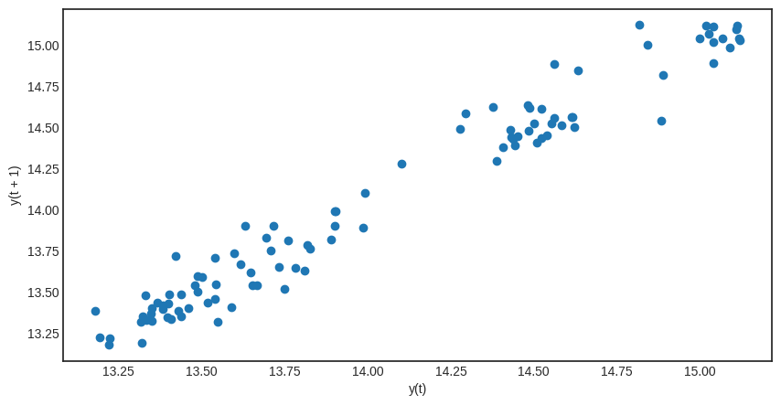

```python
from pandas.plotting import lag_plot
lag_plot(df_close.iloc[:100])
```

### This shows evidence of a strong autocorrelation, as 𝑦𝑡 values increase, nearby (lagged) values also increase

```python
# Forecast
fc=fitted.forecast(321, alpha=0.05) # 95% conf
fc=pd.DataFrame(fc)
fc['index']=test_data.index
fc.set_index('index',inplace=True)
```

### Plot the results

```python
# Make as pandas series
fc_series = fc
lower_series = test_data-0.3
upper_series = test_data+0.3
```

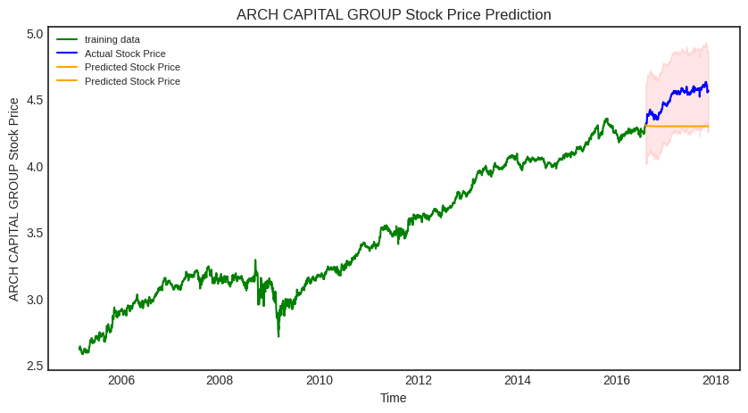

```python
# Plot
plt.figure(figsize=(10,5), dpi=100)
plt.plot(train_data,color='g', label='training data')
plt.plot(test_data, color = 'blue', label='Actual Stock Price')
plt.plot(fc_series, color = 'orange',label='Predicted Stock Price')
plt.fill_between(lower_series.index, lower_series['Close'], upper_series['Close'],color='r', alpha=.10)
plt.title('ARCH CAPITAL GROUP Stock Price Prediction')
plt.xlabel('Time')
plt.ylabel('ARCH CAPITAL GROUP Stock Price')
plt.legend(loc='upper left', fontsize=8)
plt.show()
```

```python
from statsmodels.tsa.holtwinters import ExponentialSmoothing
```

```python
fit1=ExponentialSmoothing(train_data,seasonal_periods=36,trend='add',
                          seasonal='add').fit(smoothing_level=0.2,smoothing_trend=0.001,smoothing_seasonal=0.2)
f1=fit1.forecast(321)
f1=pd.DataFrame(f1)
f1['index']=test_data.index
f1.set_index('index',inplace=True)
```

```python
#stepwise_fit=auto_arima(stock_data["Close"],start_p=1,start_q=1,max_p=3,
#                      max_q=3,m=12,seasonal=True,start_P=0,d=None,D=1,trace=True,
#                     error_action='ignore',suppress_warnings=True,
#                      stepwise=True)
#stepwise_fit.summary()
```

```python
mod=ARIMA(train_data,order=(0,1,1),seasonal_order=(2,1,0,12)).fit()
f2=mod.forecast(321)
f1['f2']=np.array(f2)
```

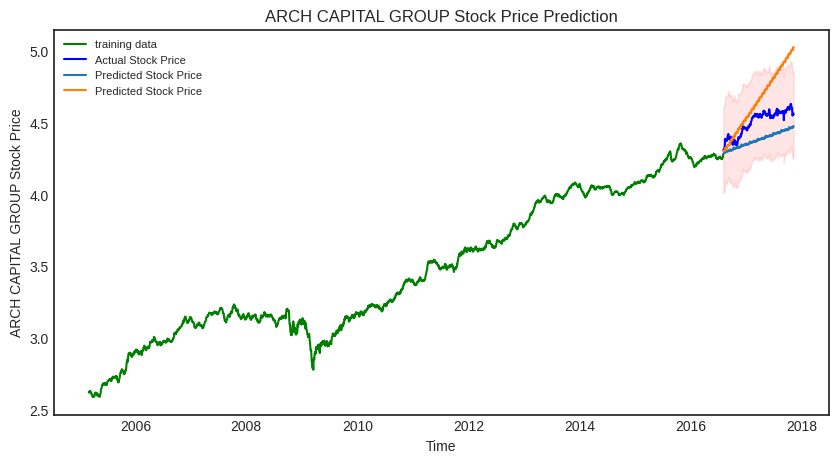

```python
plt.figure(figsize=(10,5), dpi=100)
plt.plot(fit1.fittedvalues,color='g', label='training data')
plt.plot(test_data, color = 'blue', label='Actual Stock Price')
plt.plot(f1,label='Predicted Stock Price')
plt.fill_between(lower_series.index, lower_series['Close'], upper_series['Close'],color='r', alpha=.1)
plt.title('ARCH CAPITAL GROUP Stock Price Prediction')
plt.xlabel('Time')
plt.ylabel('ARCH CAPITAL GROUP Stock Price')
plt.legend(loc='upper left', fontsize=8)
plt.show()
```

```python
# report performance
mse = mean_squared_error(test_data, f1[0])
print('MSE: ',(mse))
mae = mean_absolute_error(test_data, f1[0])
print('MAE: ',(mae))
rmse = math.sqrt(mean_squared_error(test_data, f1[0]))
print('RMSE: ',(rmse))
mape = np.mean(np.abs((test_data['Close']-f1[0])/(test_data['Close'])))
print('MAPE: ',(mape)*100,'%')
```

```
MSE:  0.016781861572311093
MAE:  0.12194526552725807
RMSE:  0.12954482456783478
MAPE:  2.6934073438289263 %
```